# Analysis for Hoecker and Higuera XXXX:

## Build composite biomass burning recrod from individual records.

Import raw charcoal count data.

```r
# Import selected regions / alaska
dataframes <- lapply(paste0(dataDir,'charData_',lakes,'.csv'),read.csv)
```

Derive and standardize charcoal accumulation rates (# cm2 yr-1, “CHAR”).

```r
# Calculate and standardize CHAR
for (i in 1:length(lakes)){
  # Calculate sediment accumulation rates (dataframes[[i]]$sedAcc) [cm/yr]
  dataframes[[i]][,'sedAcc'] <-
    (dataframes[[i]][,'cmTop']-dataframes[[i]][,'cmBot'])/
    (dataframes[[i]][,'ageTop']-dataframes[[i]][,'ageBot'])
  # Calculate charcoal accumulation rates (dataframes[[i]]$char) [#/cm2/yr]
  dataframes[[i]][,'char'] <-
    (dataframes[[i]][,'charCount']/dataframes[[i]][,'charVol'])*
    dataframes[[i]][,'sedAcc']
  # Log transform non-zero char
  nonZero <- which(dataframes[[i]][,'char'] > 0)
  transChar <- log(dataframes[[i]][nonZero,'char'])
  # Z-score transformed char
  zChar <- (transChar - mean(transChar, na.rm=T)) / sd(transChar, na.rm = T)
  # Exponentiate
  dataframes[[i]][nonZero,'char'] <- exp(zChar)
  # Average sample age (this added to work with RK scripts)
  dataframes[[i]][,'age'] <-
    round(rowMeans(dataframes[[i]][,c('ageTop','ageBot')], na.rm = T))
  # Site/lake name
  dataframes[[i]][,'lake'] <- lakes[i]
}

# Turn multiple dataframes into one long data frame
dat <- do.call(rbind,lapply(dataframes,data.frame,stringsAsFactors=TRUE))
dat <- dat[,c('char','age','lake')]
```

Execute the method for building a composite biomass burning record used in Kelly et al. 2013 (10.1073/pnas.1305069110). The method estimates the parameters of a zero-inflated log-normal (ZIL) distribution of pooled charcoal counts in continuous moving windows of a user-defined width. In this analysis, 5-year and 50-year window widths are used (2.5 and 25 half-kernel widths, respectively).

This portion of the analysis is relegated to a separate R script for clarity of the workflow. Window widths and other parameters can be manipulated within the script.

```r
source(file = file.path(codeDir,"analysis_composite.R"))
```

Plot the result, a composite record of biomass burning.

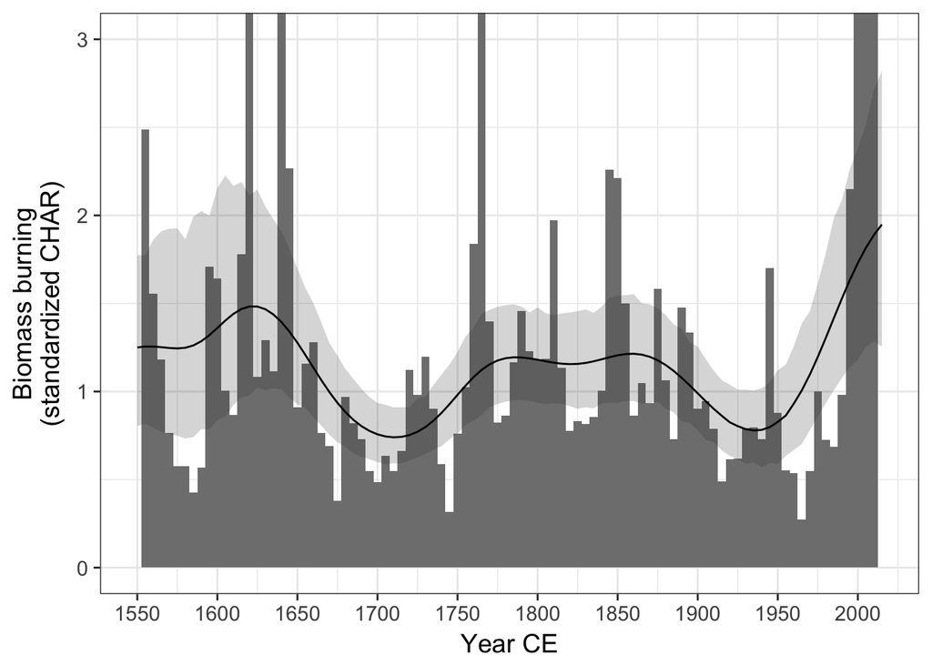

## Summarize tree demography data.

```r
tree.df %>%
  mutate(ageCE = plyr::round_any(pith,5)) %>%
  group_by(sp) %>%
  summarise(count = n())
```

[output not shown]

View time series of estimated pith dates by species.

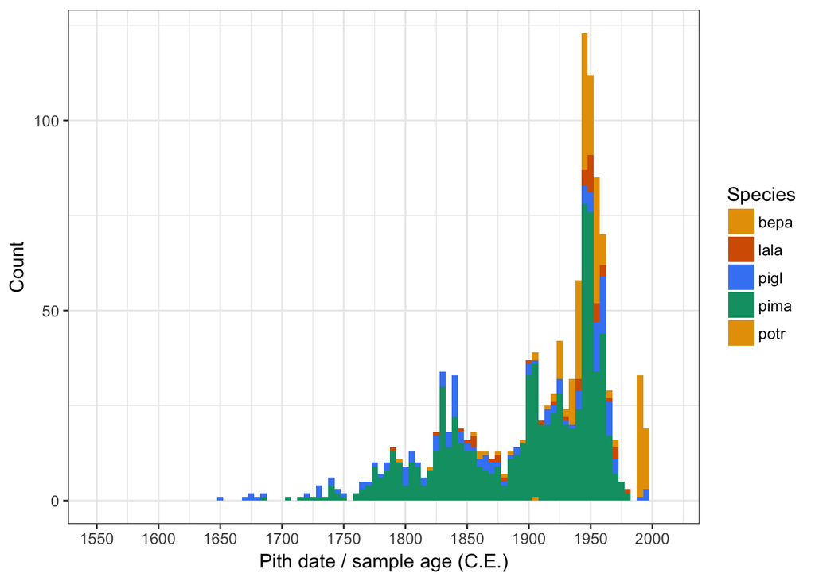

```r
speciesColors <- c("#E69F00", "#D55E00", "#4286f4","#009E73","#E69F00")

ggplot(tree.df, aes(x = pith)) + theme_bw(base_size = 12) +
  geom_histogram(stat = 'bin',
                 binwidth = 5,
                 position = 'stack',
                 aes(fill = sp)) +
  scale_fill_manual(values = speciesColors) +
  scale_x_continuous(limits = studyPeriod, breaks = seq(studyPeriod[1],studyPeriod[2],50)) +
  scale_y_continuous(breaks = c(0,50,100)) +
  labs(x = 'Pith date / sample age (C.E.)', y = 'Count', fill = 'Species')
```

## Compare proxies

Calculate correlation among fire, tree, and GOA climate records.

```r
# Modify tree dataframe
tree.cor.df <- tree.df %>%
  mutate(ageCE = plyr::round_any(pith,5)) %>%
  group_by(sp, ageCE) %>%
  summarise(count = n()) %>%
  tidyr::spread(key = sp, value = count) %>%
  mutate(bepa = ifelse(is.na(bepa),0,bepa),
         lala = ifelse(is.na(lala),0,lala),
         pigl = ifelse(is.na(pigl),0,pigl),
         pima = ifelse(is.na(pima),0,pima),
         potr = ifelse(is.na(potr),0,potr)) %>%
  mutate(all = rowSums(.[c('bepa','lala','pigl','pima','potr')]))

# Modify GOA climate dataframe
goa.temp <- goa.binned %>%
  mutate(ageCE = as.numeric(as.character(.$yearBins))) %>%
  select(-sign,-yearBins) %>%
  filter(ageCE < 1900)

combined.GOA.df <- composite.df %>%
  select(ageCE, lowMean, highMean) %>%
  inner_join(., pctBurned, by = 'ageCE') %>%
  inner_join(., goa.temp, by = 'ageCE') %>%
  left_join(., tree.cor.df, by = 'ageCE') %>%
  select(lowMean, highMean, win.pct, bin.temp, all)

corr.goa.df <- rcorr(as.matrix(combined.GOA.df), type="spearman")
```

View correlation coefficients and p-values.

```r
kable(
  corr.goa.df$r,
  caption = 'R',
)
```

R

|  | lowMean | highMean | win.pct | bin.temp | all |
| --- | --- | --- | --- | --- | --- |
| lowMean | 1.0000000 | 0.4314058 | -0.2470786 | 0.0729776 | 0.6359594 |
| highMean | 0.4314058 | 1.0000000 | 0.0789600 | 0.2322127 | 0.3611611 |
| win.pct | -0.2470786 | 0.0789600 | 1.0000000 | 0.1585945 | 0.4117778 |
| bin.temp | 0.0729776 | 0.2322127 | 0.1585945 | 1.0000000 | 0.2761007 |
| all | 0.6359594 | 0.3611611 | 0.4117778 | 0.2761007 | 1.0000000 |

```r
kable(
  corr.goa.df$P,
  caption = 'P-Value',
)
```

P-Value

|  | lowMean | highMean | win.pct | bin.temp | all |
| --- | --- | --- | --- | --- | --- |
| lowMean | NA | 0.0001925 | 0.0454949 | 0.5482515 | 0.0000060 |
| highMean | 0.0001925 | NA | 0.5285620 | 0.0530664 | 0.0187791 |
| win.pct | 0.0454949 | 0.5285620 | NA | 0.2034165 | 0.0067394 |
| bin.temp | 0.5482515 | 0.0530664 | 0.2034165 | NA | 0.0767403 |
| all | 0.0000060 | 0.0187791 | 0.0067394 | 0.0767403 | NA |

Calculate correlation among fire, tree and CRU climate records.